# Analyse de survie — Cancer colorectal (dataset colon)

Kami Victor KOBA

2026-02-22

# 1. Objectif

L’objectif de cette étude est de comparer la survie globale de patients atteints de cancer colorectal selon le traitement reçu : Observation, Levamisole, ou Levamisole + 5FU.

Nous cherchons à déterminer si un traitement est associé à une meilleure survie.

# 2. Données

Le jeu de données `colon` provient du package **survival** et contient des patients inclus dans un essai clinique.

Chaque patient apparaît deux fois : - `etype = 1` : information de rechute - `etype = 2` : information de décès

Pour analyser la **survie globale**, on conserve uniquement les observations correspondant au décès.

# 3. Préparation des données

Nous transformons la base afin d’avoir **une seule ligne par patient** et créons une variable indiquant si le décès est observé (event = 1) ou censuré (event = 0).

```
##
##     Obs     Lev Lev+5FU
##     315     310     304
```

```
##
##   0   1
## 477 452
```

Les groupes de traitement sont équilibrés et le nombre d’événements est suffisant pour réaliser une analyse de survie.

# 4. Description de la cohorte

Avant toute analyse statistique, il est nécessaire de vérifier que les groupes sont comparables au départ.

```
## N par traitement:
```

```
##
##     Obs     Lev Lev+5FU
##     315     310     304
```

```
##
## Age (moyenne, sd) par traitement:
```

```
##       trt age.mean   age.sd
## 1     Obs 59.45397 11.97344
## 2     Lev 60.11290 11.64511
## 3 Lev+5FU 59.70066 12.25523
```

```
##
## Nodes (moyenne, sd) par traitement:
```

```
##       trt nodes.mean nodes.sd
## 1     Obs   3.785256 3.728146
## 2     Lev   3.694079 3.562988
## 3 Lev+5FU   3.491525 3.416511
```

```
##
## Sexe (%):
```

```
##
##              0    1
##   Obs     47.3 52.7
##   Lev     42.9 57.1
##   Lev+5FU 53.6 46.4
```

```
##
## Décès (%):
```

```
##
##              0    1
##   Obs     46.7 53.3
##   Lev     48.1 51.9
##   Lev+5FU 59.5 40.5
```

Les caractéristiques initiales sont globalement similaires entre les groupes, ce qui permet une comparaison pertinente de la survie.

# 5. Analyse de survie (Kaplan–Meier)

Les courbes de Kaplan–Meier permettent d’estimer la probabilité de survie au cours du temps pour chaque traitement.

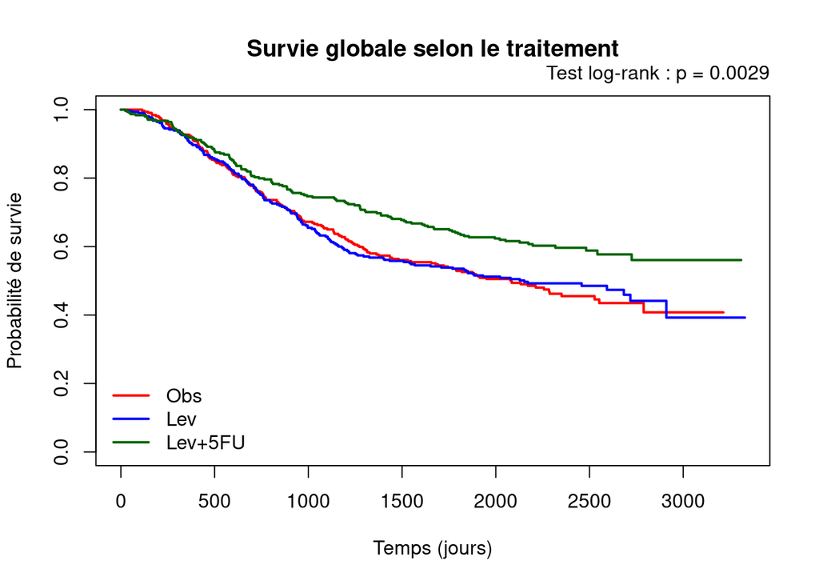

```
## [1] 0.002904348
```

Le test log-rank permet de déterminer si les différences observées entre les courbes sont compatibles avec le hasard.

# 6. Modèle de Cox

Afin de quantifier l’effet du traitement sur le risque de décès, nous utilisons un modèle de Cox.

```
## Call:
## coxph(formula = Surv(time, event) ~ trt, data = df)
##
##   n= 929, number of events= 452
##
##                coef exp(coef) se(coef)      z Pr(>|z|)
## trtLev     -0.02664   0.97371  0.11030 -0.241  0.80917
## trtLev+5FU -0.37171   0.68955  0.11875 -3.130  0.00175 **
## ---
## Signif. codes:  0 '***' 0.001 '**' 0.01 '*' 0.05 '.' 0.1 ' ' 1
##
##            exp(coef) exp(-coef) lower .95 upper .95
## trtLev        0.9737      1.027    0.7844    1.2087
## trtLev+5FU    0.6896      1.450    0.5464    0.8703
##
## Concordance= 0.536  (se = 0.013 )
## Likelihood ratio test= 12.15  on 2 df,   p=0.002
## Wald test            = 11.56  on 2 df,   p=0.003
## Score (logrank) test = 11.68  on 2 df,   p=0.003
```

Le Hazard Ratio (HR) représente le risque relatif de décès comparé au groupe Observation.

# 7. Conclusion

L’analyse de survie met en évidence une différence significative entre les traitements.

Le traitement combiné **Levamisole + 5FU** est associé à la meilleure survie et à une réduction d’environ 31% du risque de décès par rapport à l’observation.

Ces résultats suggèrent un bénéfice du traitement combiné, tout en restant interprétés comme une association statistique et non une preuve causale.